# The Visualisation of 12F Serotype

Dewi Anastasia Christina

18 April 2025

## 1. Introduction

### 1.1. Data

1. Epidata (2001-2022): Serotype-level data Version 1 (daily data 2017-2022) combined with Version 3 (epidemiological year separated into six age bands, grouped per week 2001-2017) supplied by UKHSA.
2. Weekly invasive GPSC55 cases from WGS line-list

### 1.2. Some context

Previously, Lilith use epidemiological annual data of invasive 12F cases separated into two age bands (2010/11-2016/17). We got new serotype-level epidemiological data on January 2025.

## 2. Visualisations

### 2.1. Non-heterogeneity: annually, monthly and weekly

I think we can test weekly data for non-heterogeneity model, but we have to omit the data before min(as.Date(gen$collection_date))+541

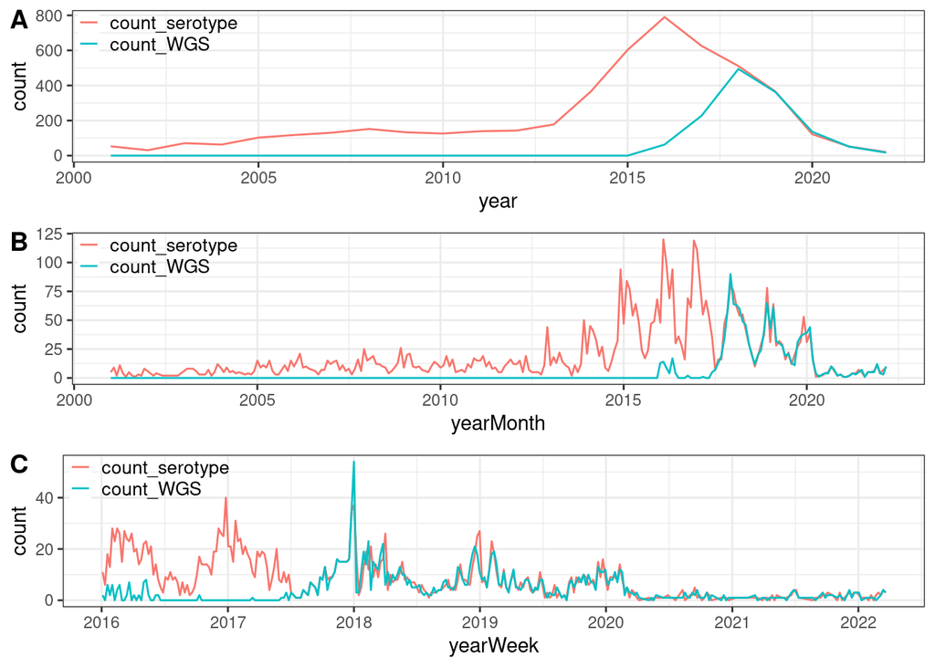

### 2.1. 3 demographic groups: annually, monthly and weekly

I think we can test weekly data for 3 age groups, but we have to omit the data before min(as.Date(gen$collection_date))+541

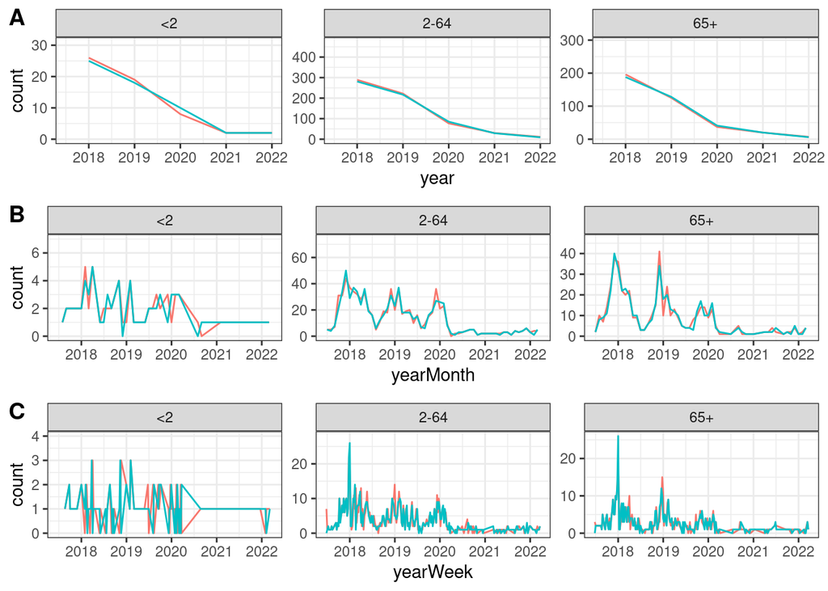

### 2.1. 6 demographic groups: annually, monthly and weekly

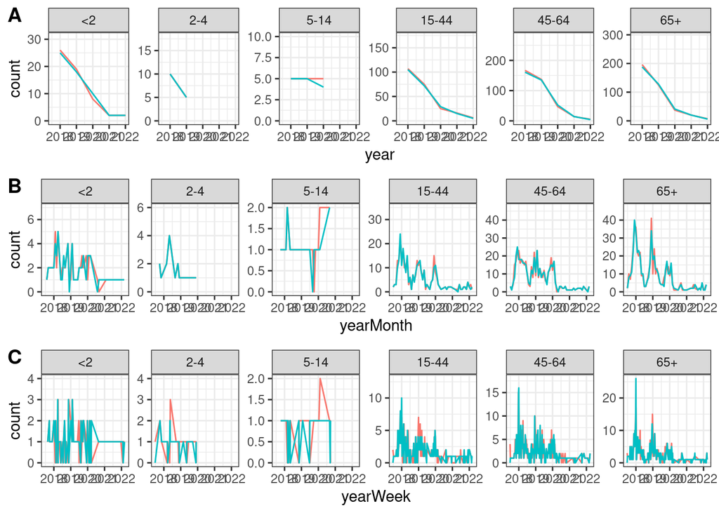

Test yearMonth and yearWeek

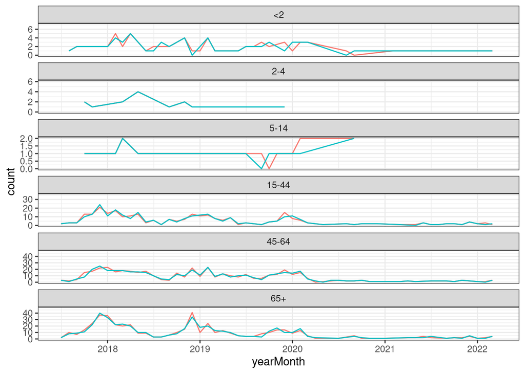

hmm, weird…

week is too chaotic in some age groups.

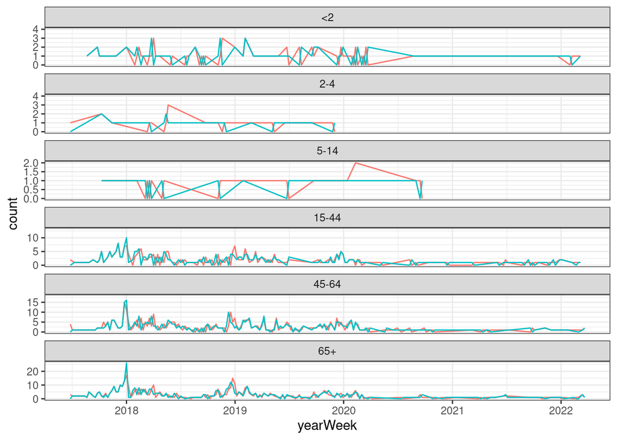

fin.